# Лабораторна робота 5

# Тема. Алгоритми пошуку

# Мета: засвоїти варіанти реалізації алгоритмів пошуку засобами Python і методи оцінювання їх складності.

## 1.Реалізація лінійного пошуку на Python

```python
# Якщо елемент не буде знайдено, виводиться -1
def linear_search(a_list, x):
    i, length = 0, len(a_list)
    while i < length and x != a_list[i]:
        i += 1
    return i if i < length else -1
```

## 2.Оцінка асимптотичну складність алгоритму лінійного пошуку в О-нотації.

Найгірший випадок: елемент відсутній у масиві або знаходиться в кінці. У цьому випадку алгоритм перевіряє всі 𝑛 елементів, тому його часова складність O(n). Найкращий випадок: якщо потрібний елемент знаходиться на першій позиції, складність буде O(1).

## 3.Бінарний пошук на Python

```python
def bin_search(a_list, x, left, right):
    if left > right or len(a_list) == 0:
        return -1
    middle = (left + right) // 2
    if a_list[middle] == x:
        return middle
    elif (a_list[middle] < x):
        return bin_search(a_list, x, middle + 1, right)
    else: # a_list[middle] > x
        return bin_search(a_list, x, left, middle - 1)
```

## 4.оцінка асимптотичну складність алгоритму бінарного пошуку в О-нотації.

Найгірший випадок:Складність алгоритму – O(log(n)), де n – довжина списку на вході.

Найкращий випадок: O(1) якщо шуканий елемент знаходиться прямо в центрі масиву після першого поділу

## 5.Функція, яка повертає датафрейм з таким складом полів: («n», «time»), де n – розмір масиву для функції linear_searh();

```python
import time
import pandas as pd



def linear_search(arr, target):
    for i in range(len(arr)):
        if arr[i] == target:
            return i
    return -1


def measure_linear_search(sizes):
    results = []
    for n in sizes:
        arr = list(range(n))  # Створюємо впорядкований масив
        target = n - 1  # Шуканий елемент (останній)

        start_time = time.time()
        linear_search(arr, target)
        end_time = time.time()

        results.append({"n": n, "time": end_time - start_time})

    return pd.DataFrame(results)

# Приклад виклику функції
df = measure_linear_search([100, 1000, 5000, 10000, 50000])
print(df)
```

[output not shown]

## 6.Функція, яка повертає датафрейм з таким складомполів: («n», «time»), де n – розмір масиву для функції bin_searh();

```python
import time
import pandas as pd

def binary_search(arr, target):
    left, right = 0, len(arr) - 1
    while left <= right:
        mid = (left + right) // 2
        if arr[mid] == target:
            return mid
        elif arr[mid] < target:
            left = mid + 1
        else:
            right = mid - 1
    return -1


def measure_binary_search(sizes):
    results = []
    for n in sizes:
        arr = list(range(n))  # Створюємо впорядкований масив
        target = n - 1  # Шуканий елемент (останній)

        start_time = time.time()
        binary_search(arr, target)
        end_time = time.time()

        results.append({"n": n, "time": end_time - start_time})

    return pd.DataFrame(results)


# Приклад виклику функції
df = measure_binary_search([100, 1000, 5000, 10000, 50000])
print(df)
```

[output not shown]

## 7.Побудова графіку залежності часу виконання процедури пошуку від розміру масиву за результатами попередніх завдань.

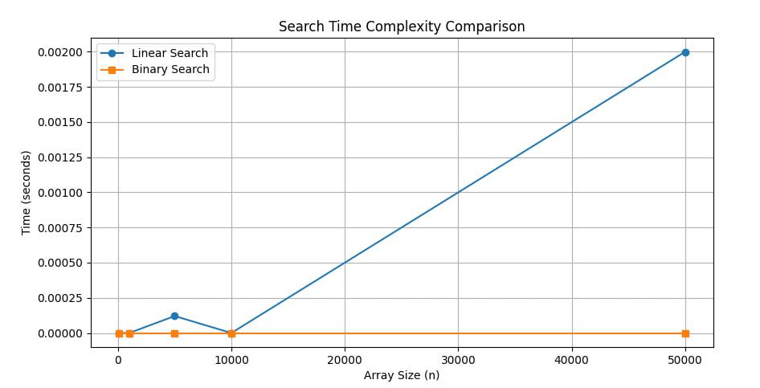

## 8.Оцінка,двох алгоритмів

Лінійний пошук має часову складність O(n), тобто час виконання зростає пропорційно до розміру масиву. Бінарний пошук має складність O(log n), що означає значно швидший пошук для великих масивів. Для малих масивів (n < 1000) різниця в часі може бути непомітною, і лінійний пошук може бути простішим у реалізації. Для середніх і великих масивів (n > 1000) бінарний пошук стає набагато ефективнішим, особливо для n > 10,000,але Бінарний пошук працює тільки на відсортованих масивах, що потрібно враховувати в реальних задачах. Отже, бінарний пошук ефективніший для великих розмірів n, особливо в діапазоні n > 1000.

## 9.Відповіді на запитання:

1. Сформулювати задачу пошуку.

Задача пошуку полягає у визначенні позиції (індексу) заданого елемента в колекції (масиві, списку, базі даних). Якщо елемент знайдено, алгоритм повертає його позицію, інакше – сигналізує про відсутність елемента.

2. Які критерії можна використовувати для оцінювання ефективності алгоритмів пошуку?

Часова складність – скільки операцій потрібно для пошуку елемента в середньому, найгіршому та найкращому випадках. Просторова складність – скільки додаткової пам’яті потребує алгоритм. Універсальність – чи алгоритм працює на будь-якому впорядкованому/невпорядкованому масиві. Стійкість до змін – чи алгоритм ефективний при динамічних змінах у структурі даних.

3. Що таке лінійний пошук і яка його асимптотична складність?

Лінійний пошук – це алгоритм, який послідовно перевіряє кожен елемент масиву до знаходження потрібного значення або до завершення перегляду всіх елементів. Найкращий випадок: O(1) (якщо елемент перший у списку). Найгірший випадок: O(n) (коли елемент знаходиться в кінці або його немає).

4. Що таке бінарний (двійковий) пошук і в чому полягає його головний принцип роботи?

Бінарний пошук – це ефективний алгоритм пошуку, що працює на відсортованих масивах. Принцип роботи:

1. Визначає середній елемент масиву.
2. Якщо шуканий елемент менший – пошук продовжується в лівій половині, якщо більший – у правій.
3. Повторюється рекурсивно або ітеративно, поки не буде знайдено елемент або межі не зійдуться.
4. Які переваги і недоліки використання бінарного пошуку порівняно з лінійним?

Переваги: Значно швидший на великих масивах (O(log n) vs O(n)). Використовує менше порівнянь. Добре підходить для статичних даних, де рідко змінюється порядок. Недоліки: Потребує відсортованого масиву. Складніший в реалізації, ніж лінійний пошук. Не підходить для динамічних структур, де дані часто змінюються.

6. Які ще алгоритми пошуку існують, окрім лінійного і бінарного?

Тернарний пошук – ділить масив на три частини замість двох (O(log n)). Пошук у хеш-таблицях – використовує хеш-функцію для доступу до елемента майже за O(1) в середньому випадку. Пошук у дереві - ефективний для баз даних, забезпечує швидкий пошук O(log n).

## 10.Висновок:

Засвоїв варіанти реалізації алгоритмів пошуку засобами Python і методи оцінювання їх складності.Навчився аналізувати часову складність алгоритмів пошуку і вибирати серед них оптимальний.